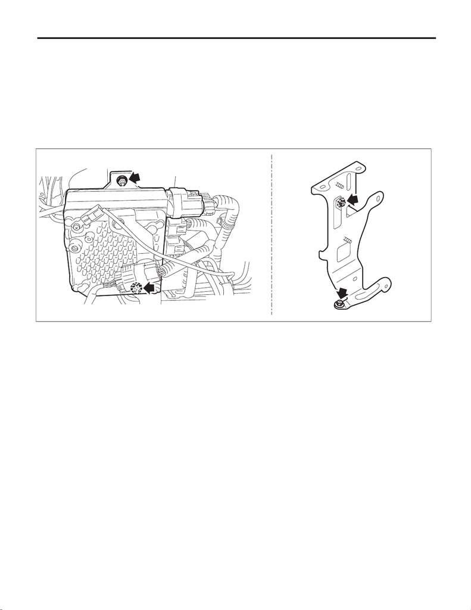

PS-84

Power Steering Control Module

POWER ASSISTED SYSTEM (POWER STEERING)

12.Power Steering Control Module

A: REMOVAL

1) Disconnect the ground cable from battery. <Ref. to NT-5, BATTERY, NOTE, Note.>

NOTE:

Disconnect the ground terminal from battery sensor.

2) Remove the power steering control module.

(1) Disconnect the connector of the power steering control module.

(2) Remove the nuts, and remove the power steering control module.

(3) Remove the bracket - control module.

B: INSTALLATION

1) Attach the bracket - control module.

Tightening torque:

7.5 N·m (0.8 kgf-m, 5.5 ft-lb)

2) Install the power steering control module.

Tightening torque:

7.5 N·m (0.8 kgf-m, 5.5 ft-lb)

3) Connect the harness connector.

CAUTION:

Make sure that the connector is securely locked.

4) Connect the battery ground terminal. <Ref. to NT-5, BATTERY, NOTE, Note.>

NOTE:

Connect the ground terminal to battery sensor.

PS-01763

[figure not shown]

PS-85

Power Steering Control Module

POWER ASSISTED SYSTEM (POWER STEERING)

C: INSPECTION

1. CHECK MOTOR UNIT

1) Turn the ignition switch to OFF.

2) Disconnect the connector from power steering unit.

3) Using a tester and test harness, check the internal resistance of the harness terminals.

Preparation tool:

Circuit tester

Between connector and terminal Standard

(PS2) No. 1 — No. 2

(PS2) No. 1 — No. 3

(PS2) No. 2 — No. 3

Less than 10 Ω

(PS2) No. 1 — Steering gearbox body

(PS2) No. 2 — Steering gearbox body

(PS2) No. 3 — Steering gearbox body

1 MΩ or more

PS4

1

PS2

D:

312

1

D3

D2

D1

PS4

PS2

PS-01707

POWER STEERING CM

MOTOR

POWER STEERING

BRACKET GROUND

[figure not shown]

PS-86

Power Steering Control Module

POWER ASSISTED SYSTEM (POWER STEERING)

2. PERFORM UNIT CHECK OF RESOLVER SENSOR

1) Turn the ignition switch to OFF.

2) Disconnect the connector from power steering unit.

3) Using a tester and test harness, check the internal resistance of the harness terminals.

Preparation tool:

Circuit tester

Between connector and terminal Standard

(PS1) No. 1 — No. 2

(PS1) No. 3 — No. 4

(PS1) No. 5 — No. 6

Less than 10 Ω

(PS1) No. 1 — Steering gearbox body

(PS1) No. 2 — Steering gearbox body

(PS1) No. 3 — Steering gearbox body

(PS1) No. 4 — Steering gearbox body

(PS1) No. 5 — Steering gearbox body

(PS1) No. 6 — Steering gearbox body

1 MΩ or more

PS1

C:

3412

7856

C5

C6

C1

C2

C3

C4

PS1

PS-01708

RESOLVER SENSOR

POWER STEERING CM

[figure not shown]

PS-87

General Diagnostic Table

POWER ASSISTED SYSTEM (POWER STEERING)

13.General Diagnostic Table

A: INSPECTION

• Hydraulic type

*1 If the tires or wheels are wider than standard, the load to power steering system is increased. Accordingly, in a condition, for

example before fluid warms-up, relief valve may work before reaching maximum turning angle. In this situation, steering effort

may become relatively heavy. When the measured hydraulic pressure is normal, there is no abnormal thing.

*2 In cold weather, steering effort may be heavy due to increased flow resistance of cold fluid. After warming-up engine, turn the

steering wheel from stop to stop several times to warm up fluid. If steering effort reduces normally, function is normal.

*3 In cold weather or with insufficient warm up of the engine, steering effort may be heavy due to excessive drop of idling when

turning the steering wheel. Start the vehicle with increasing engine speed than usual. If the steering effort returns to normal, the

function operates normally.

Trouble Possible cause Corrective action

• Steering effort is

heavy in all ranges.

• Steering effort is

heavy at stand still.

• Steering wheel

vibrates when turning.

1. Pulley belt

• Unequal length of pulley belts

• Contact with oil or grease

• Looseness or damage of the pulley belt

• Poor uniformity of the pulley belt cross section

• Pulley belt touches to pulley bottom

• Poor revolution of pulleys (except oil pump pulley)

• Poor revolution of oil pump pulley

Adjust or replace the

faulty parts.

2. Tire and wheel

• Improper tire out of specifications*1

• Improper wheel out of specifications*1

• Tires not properly inflated

Replace or reinflate the

tire and wheel.

Instruct customers.

3. Fluid

•Low fluid level

• Air entry in fluid

• Dust entry in fluid

• Fluid deterioration

• Inadequate warm up of fluid*2

Refill the fluid, bleed air,

replace or instruct cus-

tomer.

4. Idle speed

• Lower idle speed

• Excessive drop of idle speed at start or when turning the steering wheel*3

Adjust the idle speed or

instruct customer.

5. Measure the hydraulic pressure. <Ref. to PS-79, INSPECTION, Oil Pump.> Replace the faulty parts.

6. Measure the steering wheel effort. <Ref. to PS-91, MEASUREMENT OF

STEERING EFFORT (HYDRAULIC TYPE), INSPECTION, General Diagnostic

Table.>

Adjust or replace.

7. Fluid line

• Fluid leakage from fluid line

Repair or replace.

• Vehicle leads to one

side or the other.

• Returning force of

steering wheel to cen-

ter is poor.

• Steering wheel

vibrates when turning.

1. Tire and wheel

•Flat tire

• Mixed use of different tires

• Mixed use of different wheels

• Abnormal wear of tire

• Unequal tread remaining

• Unequal pressure of tire

Adjust, repair or replace

the tire and wheel.

2. Front alignment

• Improper or unequal caster

• Improper or unequal toe-in

• Loose suspension connections

Adjust or retighten.

3. Others

• Damaged joint assembly

• Unbalance of ground clearance

• Unbalance of load

Replace or adjust the

faulty parts, or instruct

customer.

4. Measure the steering wheel effort. <Ref. to PS-91, MEASUREMENT OF

STEERING EFFORT (HYDRAULIC TYPE), INSPECTION, General Diagnostic

Tabl e.>

Adjust or replace the

faulty parts.

[figure not shown]

PS-88

General Diagnostic Table

POWER ASSISTED SYSTEM (POWER STEERING)

• Electric type

NOTE:

When performing repeated steering operation with the vehicle at standstill, the steering effort may be tem-

porarily heavy because the heat generated in the system activates the power steering protection control. This

is not a malfunction caused by the steering system. After a while, it will return to normal steering effort. (In this

case, the steering warning light will not come on and there will be no DTC.)

Trouble Possible cause Corrective action

• Steering effort is heavy in all

ranges.

• Steering effort is heavy at

stand still.

• Steering wheel vibrates

when turning.

1. Tire and wheel

• Improper tire out of specifications

• Improper wheel out of specification

• Tires not properly inflated

Replace or reinflate the tire

and wheel.

2. Measure the steering wheel effort. <Ref. to PS-92, MEA-

SUREMENT OF STEERING EFFORT (ELECTRIC TYPE),

INSPECTION, General Diagnostic Table.>

Adjust or replace the faulty

parts.

• Vehicle leads to one side or

the other.

• Returning force of steering

wheel to center is poor.

• Steering wheel vibrates

when turning.

1. Tire and wheel

• Flat tire

• Mixed use of different tires

• Mixed use of different wheels

• Abnormal wear of tire

• Unequal tread remaining

• Unequal pressure of tire

Adjust, repair or replace the

tire and wheel.

2. Front wheel alignment

• Improper or unequal caster

• Improper or unequal toe-in

• Loose suspension connections

Adjust or retighten.

3. Measure the steering wheel effort. <Ref. to PS-92, MEA-

SUREMENT OF STEERING EFFORT (ELECTRIC TYPE),

INSPECTION, General Diagnostic Table.>

Adjust or replace the faulty

parts.